# COVID-19 data Analysis

## 4.6 Seoul floating population EDA

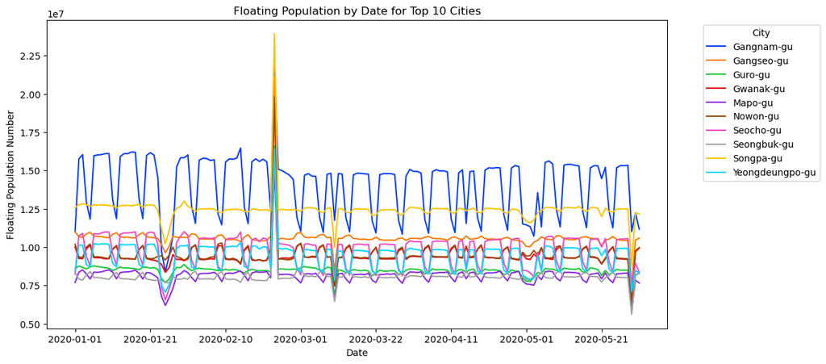

```python
# Grouping data by 'date' and 'city', summing the 'fp_num' for each group
city_population = seoul_floating.groupby(['date', 'city'])['fp_num'].sum().reset_index()

top_10_cities = city_population.groupby('city')['fp_num'].sum().nlargest(10).index

filtered_data = city_population[city_population['city'].isin(top_10_cities)]

pivot_data = filtered_data.pivot(index='date', columns='city', values='fp_num')

pivot_data.plot(figsize=(12, 6))
plt.xlabel('Date')
plt.ylabel('Floating Population Number')
plt.title('Floating Population by Date for Top 10 Cities')
plt.legend(title='City', bbox_to_anchor=(1.05, 1), loc='upper left')
plt.show()
```

#### Let's examine the significant decrease at the end of January.

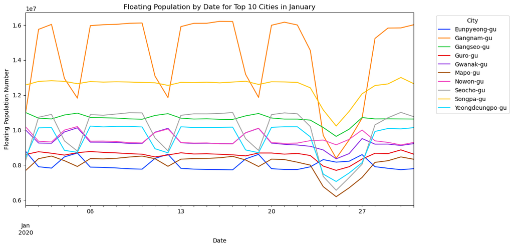

```python
seoul_floating['date'] = pd.to_datetime(seoul_floating['date'])

# Filtering the data for January
january_data = seoul_floating[seoul_floating['date'].dt.month == 1]

# Grouping the data by 'date' and 'city', summing the 'fp_num' for each group
city_population = january_data.groupby(['date', 'city'])['fp_num'].sum().reset_index()

top_10_cities = city_population.groupby('city')['fp_num'].sum().nlargest(10).index

filtered_data = city_population[city_population['city'].isin(top_10_cities)]

pivot_data = filtered_data.pivot(index='date', columns='city', values='fp_num')

pivot_data.plot(figsize=(12, 6))
plt.xlabel('Date')
plt.ylabel('Floating Population Number')
plt.title('Floating Population by Date for Top 10 Cities in January')
plt.legend(title='City', bbox_to_anchor=(1.05, 1), loc='upper left')
plt.show()
```

24 Jan to 26 Jan (Fri to Sun) was a Korean Public Holiday - "Seollal"

#### This explains migration out from all major Seoul districts.

Seollal, or Korean Lunar New Year, is a major holiday in the lives of South Koreans. Seollal comes in January or February and involves family visits, ancestral rites, eating of traditional foods and playing of Korean games.

#### Let's look at the significant spike in February

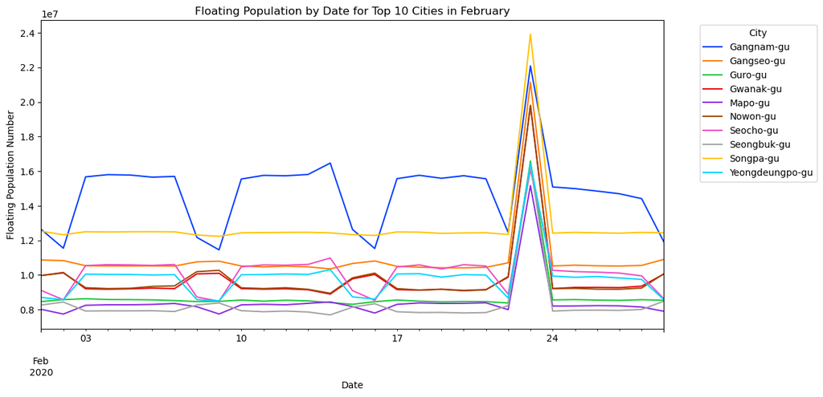

```python
seoul_floating['date'] = pd.to_datetime(seoul_floating['date'])

# Filter the data for February
february_data = seoul_floating[seoul_floating['date'].dt.month == 2]

city_population = february_data.groupby(['date', 'city'])['fp_num'].sum().reset_index()

top_10_cities = city_population.groupby('city')['fp_num'].sum().nlargest(10).index

filtered_data = city_population[city_population['city'].isin(top_10_cities)]

pivot_data = filtered_data.pivot(index='date', columns='city', values='fp_num')

pivot_data.plot(figsize=(12, 6))
plt.xlabel('Date')
plt.ylabel('Floating Population Number')
plt.title('Floating Population by Date for Top 10 Cities in February')
plt.legend(title='City', bbox_to_anchor=(1.05, 1), loc='upper left')
plt.show()
```

Feb 23, 2020, South Korea has raised its coronavirus alert to the "highest level" as confirmed case numbers keep rising.

#### This explains the migration increase in districts that are largest by registered population like Songpa-gu. Songpa is the largest district in Seoul by population. Strange that after high Sunday population gets back to average Monday.

**Suggestion:**  
Holiday Planning: Public holidays like Seollal can lead to mass migrations. The government should have a proactive strategy in place to manage and regulate travel during these times to prevent large-scale outbreaks.

Effective Communication: Effective communication strategies are crucial during outbreaks. The public needs to be informed of the situation, preventive measures, and vaccination campaigns. Public health campaigns should be designed to address various age groups.

# 5. Summary and Suggestions

**1. Regional Focus:** Daegu is the leading province in confirmed COVID-19 cases, and from the confirmed cases map, it's clear that the main hotspots are in Daegu and Seoul regions, with Daegu standing out with a significant number of cases. The initial outbreak linked to the Shincheonji Church had a profound impact on the region.

**2. Shincheonji Church Impact:** The Shincheonji Church outbreak was a major turning point in the pandemic. A significant number of confirmed cases can be directly attributed to events at this church. It led to a sudden spike in cases and a dramatic reaction from the local population.

**3. Demographic Correlations:** There is a notable correlation between age and deceased rates. Specifically, the elderly population (60-80+) has a higher risk of severe outcomes. It's essential to prioritize vaccination and protection measures for this age group.

**4. Age Groups and Infection Rates:** The analysis revealed that the 20's age group had a higher number of confirmed cases compared to other age groups. This demographic insight is crucial for targeting testing and vaccination efforts.

**Suggestions:**

**1. Regional Preparedness:** Given Daegu's history as a hotspot, it's essential to ensure that the healthcare infrastructure and testing facilities in this region are well-prepared to handle a surge in cases. Regular testing and monitoring should be maintained.

**2. Religious Gatherings:** Learning from the Shincheonji Church outbreak, it's important to have a system for monitoring and regulating large gatherings, especially in enclosed spaces. Clear guidelines should be in place for religious institutions to follow during outbreaks.

**3. Elderly Protection:** To reduce mortality rates, a strong focus should be placed on protecting the elderly population, including prioritizing them for vaccination and ensuring they have access to healthcare.

**4. Targeted Testing:** Given the higher number of cases in the 20's age group, it's important to conduct targeted testing in educational institutions and areas frequented by young adults.

**5. Holiday Planning:** Public holidays like Seollal can lead to mass migrations. The government should have a proactive strategy in place to manage and regulate travel during these times to prevent large-scale outbreaks.

**6. Effective Communication:** Effective communication strategies are crucial during outbreaks. The public needs to be informed of the situation, preventive measures, and vaccination campaigns. Public health campaigns should be designed to address various age groups.

**7. Data-Driven Decision Making:** Continue to use data science techniques for real-time monitoring of infection rates, demographics, and other relevant factors to make informed decisions during the next wave of the pandemic.

**8. Emergency Response:** In case of a significant spike in cases, have a well-defined emergency response plan that includes mobilizing medical resources, setting up temporary treatment centers, and implementing strict containment measures.

**Preparedness and vigilance are key in combating the ongoing pandemic and any potential future waves. By using data-driven insights and targeted strategies, your country can better respond to challenges and protect its population.**